# Machine Learning Tutorial Using `caret`

Applied to the TB NanoString data

W. Evan Johnson

2026-05-21

```r
#install.packages(c("tidyverse", "caret", "DT", "randomForest", "nnet", "e1071", "gbm", "pROC"))


suppressMessages({
  library(tidyverse)
  library(caret)
  library(DT)
  library(randomForest)
  library(nnet)
  library(e1071)
  library(gbm)
  library(pROC)
})
set.seed(0)
```

# Overview

This notebook demonstrates using `caret::train()` to build classifiers for the TB Nanostring dataset. We’ll load data, split train/test, fit multiple algorithms, compare accuracies, and plot results.

## 0. Introduction: TB NanoString Dataset

This dataset is derived from a published study in Clinical Infectious Diseases (Kaipilyawar et al., 2022) that aimed to distinguish active **tuberculosis (TB)** from **latent TB infection (LTBI)** using gene expression measured in peripheral blood. The authors selected a panel of 107 TB-relevant genes and profiled their expression levels in blood samples from individuals with active disease and those with latent infection.

Key features of the dataset:

- Rows correspond to individual patients.
- First column is the TB status (active TB vs. LTBI), typically coded as a binary factor.
- Remaining columns are expression levels (e.g. normalized counts or log-transformed intensities) for 107 TB-associated genes (NanoString panel).
- The goal is to use these gene expression features as predictors in classification models that can distinguish active TB vs LTBI.

This makes the dataset a classic high-dimensional, moderate sample size scenario: many predictors relative to samples. It’s well suited for demonstrating feature selection, penalized models, and cross-validated machine learning methods.

In our analyses, we treat the **TB status** as the response (binary classification) and the 107 gene expression features as predictors. A key challenge is to avoid **overfitting**, especially given the high dimensionality, which is why cross validation, regularization, and careful model comparison are essential.

### Load data

```r
TBnanostring <- readRDS("TBnanostring.rds")
TBnanostring[[1]] <- as.factor(TBnanostring[[1]])
colnames(TBnanostring)[1] <- "TB_Status"
datatable(TBnanostring, options = list(pageLength = 10))
```

|  | TB_Status | AGAP9 | AIRE | ANKRD22 | APOL1 | APOL6 | ATP1A1 | BATF2 | BCL6 | BLK | C16orf7 | C1QB | C1QC | C4ORF18 | C5 | CCDC14 | CCDC78 | CCR6 | CD1C | CD79A | CD79B | CIRBP | CTSA | CXCR5 | CXorf40B | CYP4F3 | DARS2 | DERA | DUSP3 | … |
| --- | --- | --- | --- | --- | --- | --- | --- | --- | --- | --- | --- | --- | --- | --- | --- | --- | --- | --- | --- | --- | --- | --- | --- | --- | --- | --- | --- | --- | --- | --- |
| Sample_1 | TB | -0.3567952891613851 | -0.2428400750618191 | 1.207905558493485 | 1.555417591919483 | 1.253195633963252 | -1.19773967725765 | 1.267449740074419 | 1.44405564668365 | 0.08830775445314894 | 2.019266536890396 | 0.7516975319176218 | 0.3728128299227613 | -1.044097012784921 | -0.6537817263494731 | -0.6655872996869874 | 0.3941787796749492 | -0.731969022018938 | 0.2519854285556507 | 0.1100454335247583 | 0.02071439218469675 | -0.3212363894966508 | -1.149180848797646 | 0.3352513020122072 | -0.5414855353359561 | 1.274072363654428 | -0.1299396035972255 | -2.397303286864058 | 0.2299788779102083 | … |
| Sample_2 | TB | -0.5855965092374802 | -1.306416297601576 | 1.216041831341325 | 0.5208883402769555 | -0.07293285737957687 | -1.090330219535047 | 0.3970186823102559 | 0.5046354934802626 | -1.668252626535817 | 1.699008243667597 | 1.266415983002439 | 1.397989287308514 | 0.7745526015112829 | 0.5992139442150497 | -1.543550285725023 | 0.004670462482051654 | -1.484418435922324 | 0.3703776259266084 | -2.017855314157253 | -1.50285848270686 | -1.029017144667262 | 1.144979693267663 | -1.591693600854994 | -0.650163550455721 | 0.9066523154368646 | -0.9552105910616149 | 0.5002664813531675 | 1.186088490147909 | … |
| Sample_3 | TB | -0.7078443755887588 | 0.4544570754679451 | 0.1840317405129417 | 0.9494341145965206 | 1.644055869109122 | 0.502818498776224 | 0.5904435779994958 | 0.2033804354046358 | -1.052170149038109 | 0.1905297652957624 | 0.1035590670298391 | 0.002535352876393561 | 1.497504717120949 | 1.111576237536498 | -0.8580099443371357 | -0.675949760725112 | -0.9478361361919522 | -1.131327775946374 | -0.9823028457157846 | -1.345413654355336 | -0.550787253089989 | 1.197782679137242 | -0.9561950288944006 | -0.4921720574098309 | 0.1244443090172449 | -0.7795466235788089 | -0.6559051562414868 | 0.6930788083993142 | … |
| Sample_4 | TB | -1.031494667575215 | -0.600953084668492 | 1.628997686518667 | 2.075581508023125 | 1.823098909982189 | -1.307260034784574 | 1.376982284915563 | 1.847995219384217 | -1.361940589988246 | 2.524736151391167 | 0.755247441115648 | 0.3101495804997122 | 1.163219685390775 | -1.211930639904139 | -1.689793585506124 | 0.5001794710387819 | -1.10819211956498 | -1.193657466264923 | -1.112137911596951 | -1.33186843527569 | -0.7038541523416637 | 0.5308060675652948 | -1.099250316818298 | -0.9543184887761932 | 0.4315414607187606 | -2.026026663896097 | -0.7080736613811327 | 2.244592066682114 | … |
| Sample_5 | TB | 0.9067240290496833 | -0.1348924583178322 | -1.246894792845696 | -1.909669345338767 | -1.884188394186358 | 0.5920268788386729 | -1.565009666862524 | 0.2623956965346229 | 0.820643298328746 | -0.6990454334548679 | -1.083580214103867 | -0.6644456998932498 | 1.952931401028057 | 0.2914324531183866 | 0.8068929732375072 | 0.3842083479338066 | 1.088422222794646 | 1.249115329733536 | 0.9866711547788964 | 0.9104379020429241 | 0.3096601100166029 | -0.1476334293752958 | 0.8238985049492284 | 0.5323003625478224 | -0.004769889750576167 | 0.6436695769010405 | 1.619851589921788 | 0.2219999392611381 | … |
| Sample_6 | TB | -1.83851797105418 | -0.1280090784823144 | 0.8316545568380391 | 1.545006176944255 | 0.7208395835658897 | -1.791034149237936 | 1.348357662074938 | 1.147202275569644 | -1.456526606519168 | 1.041255815744687 | 1.063157431296947 | 0.5869006815956217 | 0.1411222404339071 | 0.4314394118862134 | -1.099506015673339 | -1.109208522979346 | -0.8445763418653442 | -1.513864896772926 | -1.772087484684398 | -1.745419947274584 | -1.684252106610131 | 0.7902316529489498 | -1.834249440392554 | -2.109834739591115 | -0.1924586523473725 | -2.314056444090808 | -0.4059249727368296 | 1.014671428328334 | … |
| Sample_7 | TB | 0.05707858493869713 | -1.069854815292915 | 1.189719488865898 | 0.5402351126887245 | 0.7031789856392341 | -0.3818936938393588 | 0.3827145880386386 | 0.8829995825248439 | -0.7671685890744196 | 0.4830399349631236 | -0.5537144551966539 | -0.2835549663622023 | 0.4692120867406758 | -0.1797230425235556 | -0.5594571787153348 | 0.6181745797269812 | -0.9181663430658387 | -0.4642661301471259 | -0.5040647744700524 | -0.4370386919607227 | 1.016509577140669 | -0.1904821171775223 | -0.4032354212848691 | 0.4023719199114419 | 2.167110090536964 | -0.1801868239153136 | -0.6521957193814021 | -0.6645721100370381 | … |
| Sample_8 | TB | -1.883431240167627 | -0.3126381478393918 | 1.50828543722368 | 0.640879601402786 | 2.013017835850941 | -2.172355556174608 | 1.538902864967792 | 0.1354778929013789 | -1.597201021442571 | 1.001035121012908 | 0.9860346466697851 | 0.5004784541589815 | 2.048798646933404 | 0.415294373849733 | -1.257503350664715 | 0.06130851992982272 | -1.950098254224667 | -0.9548917291379766 | -2.009115587082828 | -2.205184564841673 | -1.395130230563012 | -0.6037633826390437 | -2.0294814108926 | -0.01456281910193487 | 0.3890934324866815 | -1.338975631149127 | -2.174430969936838 | 0.2151384800074111 | … |
| Sample_9 | TB | -1.420386185986475 | 0.515383912267111 | 2.610736305246323 | 2.290270059911697 | 2.319317923810889 | -1.455672628594579 | 2.579743829161462 | 0.6216968649724902 | -1.825897128894175 | 1.524702707602241 | 2.241698148500488 | 2.236351022920394 | 0.6611313274262467 | 1.71147702236411 | -0.8662274369939202 | 0.1874593189327216 | -1.231761445517768 | -2.792921964006282 | -1.568631440608613 | -2.074186261695775 | -1.376791283756899 | 1.411948406363706 | -1.644780614603827 | -1.646583654183484 | 0.009585044330324512 | -1.40905778549676 | -1.238000970587481 | 2.511139673095197 | … |
| Sample_10 | TB | -1.38629357623991 | 0.4353941807468526 | 1.785281524644318 | 1.802817415598585 | 2.251563891720713 | -1.607405208737903 | 1.837433876454194 | 1.030657791301887 | -1.470958653056692 | 1.102376348186373 | 1.202236468820842 | 1.277364549709066 | 0.2999661591271855 | 1.423920466821625 | -1.199193801551537 | -0.1949666172492625 | -1.335260518417128 | -1.314502010055313 | -1.214617477447743 | -1.809972298861618 | -1.88626746616501 | 0.4951357059648722 | -1.568400619543112 | -1.519260006773639 | 0.596428364048616 | -1.774390528190914 | -1.811676935566049 | 1.057072629238347 | … |

[output cut: 169 more lines]

## 1. The `caret` Package

The `caret` (Classification And REgression Training) package provides a unified interface to train, tune, and evaluate machine learning models in R. Instead of learning different syntax for each algorithm (e.g., `glm`, `knn`, `randomForest`, `nnet`), caret offers a consistent workflow through a single function: `train()`.

Caret supports over **230 different algorithms**, each wrapped in a standardized format. A full list is available in the [caret model documentation](https://topepo.github.io/caret/available-models.html).

Key advantages of caret:

- **Unified syntax:** The same code structure works across models.
- **Built-in cross-validation:** Automatically handles resampling and tuning parameters.
- **Performance metrics:** Supports accuracy, ROC/AUC, and other summaries.
- **Variable importance and visualization:** Provides generic tools (`varImp`, `ggplot`) for comparing models.

For example, both a logistic regression and a random forest can be trained using nearly identical code:

```r
train_glm <- train(TB_Status ~ ., method = "glm", data = train_data, trControl = ctrl_cv)
train_rf  <- train(TB_Status ~ ., method = "rf",  data = train_data, trControl = ctrl_cv)
```

Predictions and performance evaluation are then handled in the same way:

```r
pred_glm <- predict(train_glm, test_data)
pred_rf  <- predict(train_rf, test_data)
confusionMatrix(pred_glm, test_data$TB_Status)
confusionMatrix(pred_rf, test_data$TB_Status)
```

This consistency makes caret ideal for **teaching**, **model comparison**, and **applied research**.  
In this notebook, we’ll use `caret::train()` to build and evaluate multiple classifiers on the TB NanoString dataset.

## 2. Partition: 70/30 (train/test)

```r
set.seed(0)
y <- TBnanostring$TB_Status
train_index <- createDataPartition(y, p = 0.7, list = FALSE)
train_data <- TBnanostring[train_index, ]
test_data  <- TBnanostring[-train_index, ]
dim(train_data); dim(test_data)
```

```
## [1] 126 108
```

```
## [1]  53 108
```

```r
table(train_data$TB_Status)
```

```
##
##   TB LTBI
##   56   70
```

```r
table(test_data$TB_Status)
```

```
##
##   TB LTBI
##   23   30
```

## 3. Understanding ROC Curves and AUC

Before training models, we’ll introduce ROC curves and AUC.

### What is an ROC curve?

- ROC = Receiver Operating Characteristic.
- Plots True Positive Rate vs. False Positive Rate across thresholds.
- Closer to top-left corner = better model.

### What is AUC?

- AUC = Area Under the Curve.
- Measures discrimination between classes (0.5 = random, 1.0 = perfect).
- Unaffected by class imbalance.

### Example ROC curve

```r
library(pROC)
set.seed(123)
true_labels <- factor(sample(c("TB", "LTBI"), 100, replace = TRUE))
predicted_prob <- runif(100)
roc_obj <- roc(true_labels, predicted_prob, levels = c("LTBI", "TB"))
```

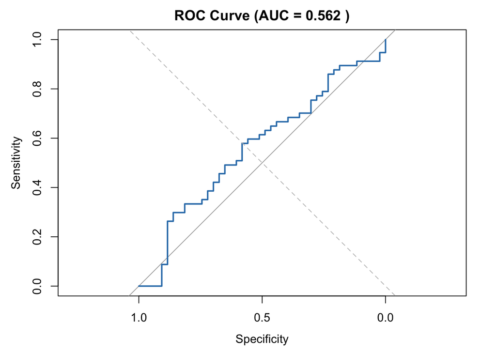

```r
auc_val <- auc(roc_obj)
plot(roc_obj, col = "#2C7BB6", lwd = 2, main = paste("ROC Curve (AUC =", round(auc_val, 3), ")"))
abline(a = 0, b = 1, lty = 2, col = "gray")
```

## 4. TrainControl objects

The `trainControl()` function in caret defines how model training and performance evaluation are performed — i.e., the resampling strategy, performance metrics, and prediction saving options. It doesn’t fit the model itself — it just tells `train()` how to do it.

```r
ctrl_cv <- trainControl(method = "repeatedcv", number = 5, repeats = 3,
                        classProbs = TRUE, summaryFunction = twoClassSummary,
                        savePredictions = "final", verboseIter = FALSE)

ctrl_none <- trainControl(method = "none", classProbs = TRUE, summaryFunction = twoClassSummary)

set.seed(123)
rf_model <- train(TB_Status ~ ., data = train_data,
                   method = "rf",
                   metric = "ROC", trControl = ctrl_cv)

summary(rf_model)
```

```
##                 Length Class      Mode
## call               4   -none-     call
## type               1   -none-     character
## predicted        126   factor     numeric
## err.rate        1500   -none-     numeric
## confusion          6   -none-     numeric
## votes            252   matrix     numeric
## oob.times        126   -none-     numeric
## classes            2   -none-     character
## importance       107   -none-     numeric
## importanceSD       0   -none-     NULL
## localImportance    0   -none-     NULL
## proximity          0   -none-     NULL
## ntree              1   -none-     numeric
## mtry               1   -none-     numeric
## forest            14   -none-     list
## y                126   factor     numeric
## test               0   -none-     NULL
## inbag              0   -none-     NULL
## xNames           107   -none-     character
## problemType        1   -none-     character
## tuneValue          1   data.frame list
## obsLevels          2   -none-     character
## param              0   -none-     list
```

```r
rf_pred <- predict(rf_model, test_data)
confusionMatrix(rf_pred, test_data$TB_Status)
```

```
## Confusion Matrix and Statistics
##
##           Reference
## Prediction TB LTBI
##       TB   20    4
##       LTBI  3   26
##
##                Accuracy : 0.8679
##                  95% CI : (0.7466, 0.9452)
##     No Information Rate : 0.566
##     P-Value [Acc > NIR] : 2.35e-06
##
##                   Kappa : 0.7325
##
##  Mcnemar's Test P-Value : 1
##
##             Sensitivity : 0.8696
##             Specificity : 0.8667
##          Pos Pred Value : 0.8333
##          Neg Pred Value : 0.8966
##              Prevalence : 0.4340
##          Detection Rate : 0.3774
##    Detection Prevalence : 0.4528
##       Balanced Accuracy : 0.8681
##
##        'Positive' Class : TB
##
```

```r
# ROC and AUC
rf_probs <- predict(rf_model, test_data, type = "prob")[, "TB"]
rf_roc <- roc(test_data$TB_Status, rf_probs, levels = rev(levels(test_data$TB_Status)))
```

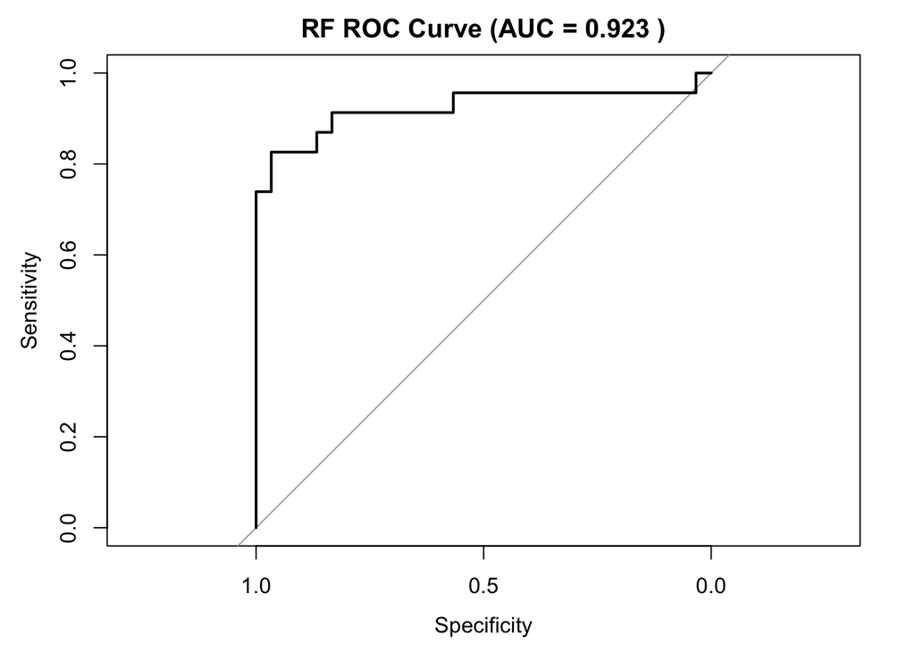

```r
plot(rf_roc, main = paste("RF ROC Curve (AUC =", round(auc(rf_roc), 3), ")"))
```

```r
auc(rf_roc)
```

```
## Area under the curve: 0.9232
```

## 6. k-Nearest Neighbors (KNN)

The KNN algorithm classifies a sample based on the majority label among its k nearest neighbors in the feature space. It’s simple and effective for low-dimensional, well-scaled data.

```r
set.seed(123)
knn_model <- train(TB_Status ~ ., data = train_data,
                   method = "knn",
                   metric = "ROC", tuneLength = 2,
                   trControl = ctrl_cv, preProcess = c("center", "scale"))

knn_model
```

```
## k-Nearest Neighbors
##
## 126 samples
## 107 predictors
##   2 classes: 'TB', 'LTBI'
##
## Pre-processing: centered (107), scaled (107)
## Resampling: Cross-Validated (5 fold, repeated 3 times)
## Summary of sample sizes: 101, 100, 101, 101, 101, 101, ...
## Resampling results across tuning parameters:
##
##   k  ROC        Sens       Spec
##   5  0.9221501  0.8277778  0.9428571
##   7  0.9335498  0.8454545  0.9380952
##
## ROC was used to select the optimal model using the largest value.
## The final value used for the model was k = 7.
```

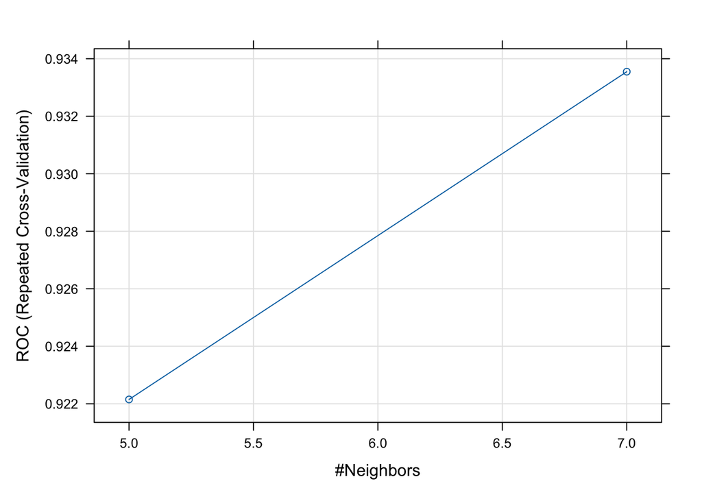

```r
plot(knn_model)
```

```r
# Predictions and performance
knn_pred <- predict(knn_model, test_data)
confusionMatrix(knn_pred, test_data$TB_Status)
```

```
## Confusion Matrix and Statistics
##
##           Reference
## Prediction TB LTBI
##       TB   17    0
##       LTBI  6   30
##
##                Accuracy : 0.8868
##                  95% CI : (0.7697, 0.9573)
##     No Information Rate : 0.566
##     P-Value [Acc > NIR] : 4.404e-07
##
##                   Kappa : 0.7623
##
##  Mcnemar's Test P-Value : 0.04123
##
##             Sensitivity : 0.7391
##             Specificity : 1.0000
##          Pos Pred Value : 1.0000
##          Neg Pred Value : 0.8333
##              Prevalence : 0.4340
##          Detection Rate : 0.3208
##    Detection Prevalence : 0.3208
##       Balanced Accuracy : 0.8696
##
##        'Positive' Class : TB
##
```

```r
# ROC and AUC
knn_probs <- predict(knn_model, test_data, type = "prob")[, "TB"]
knn_roc <- roc(test_data$TB_Status, knn_probs, levels = rev(levels(test_data$TB_Status)))
```

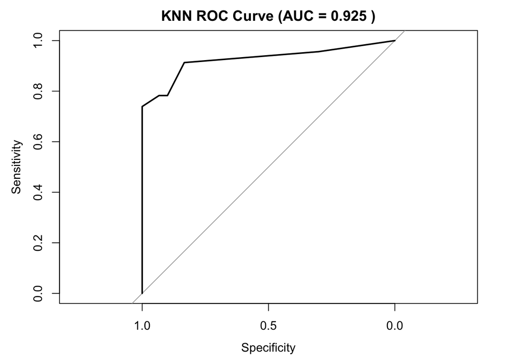

```r
plot(knn_roc, main = paste("KNN ROC Curve (AUC =", round(auc(knn_roc), 3), ")"))
```

```r
auc(knn_roc)
```

```
## Area under the curve: 0.9254
```

Interpretation: KNN performance depends heavily on the scaling of variables and the choice of k, which is tuned automatically using cross-validation.

## 7. Random Forest

Random forests are ensembles of decision trees that aggregate many weak learners to produce a strong classifier. They handle high-dimensional data and rank variable importance effectively.

```r
set.seed(123)
rf_model <- train(TB_Status ~ ., data = train_data,
                  method = "rf", metric = "ROC",
                  importance = TRUE, trControl = ctrl_cv)

rf_model
```

```
## Random Forest
##
## 126 samples
## 107 predictors
##   2 classes: 'TB', 'LTBI'
##
## No pre-processing
## Resampling: Cross-Validated (5 fold, repeated 3 times)
## Summary of sample sizes: 101, 100, 101, 101, 101, 101, ...
## Resampling results across tuning parameters:
##
##   mtry  ROC        Sens       Spec
##     2   0.9507576  0.8277778  0.9285714
##    54   0.9404221  0.8393939  0.9285714
##   107   0.9410534  0.8333333  0.9238095
##
## ROC was used to select the optimal model using the largest value.
## The final value used for the model was mtry = 2.
```

```r
rf_pred <- predict(rf_model, test_data)
confusionMatrix(rf_pred, test_data$TB_Status)
```

```
## Confusion Matrix and Statistics
##
##           Reference
## Prediction TB LTBI
##       TB   20    4
##       LTBI  3   26
##
##                Accuracy : 0.8679
##                  95% CI : (0.7466, 0.9452)
##     No Information Rate : 0.566
##     P-Value [Acc > NIR] : 2.35e-06
##
##                   Kappa : 0.7325
##
##  Mcnemar's Test P-Value : 1
##
##             Sensitivity : 0.8696
##             Specificity : 0.8667
##          Pos Pred Value : 0.8333
##          Neg Pred Value : 0.8966
##              Prevalence : 0.4340
##          Detection Rate : 0.3774
##    Detection Prevalence : 0.4528
##       Balanced Accuracy : 0.8681
##
##        'Positive' Class : TB
##
```

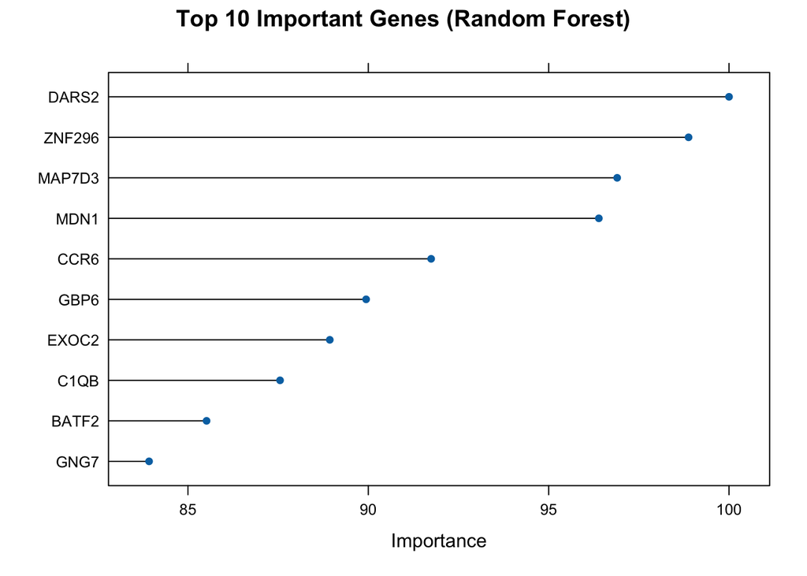

```r
# Variable Importance
rf_imp <- varImp(rf_model, scale = TRUE)
plot(rf_imp, top = 10, main = "Top 10 Important Genes (Random Forest)")
```

```r
# ROC and AUC
rf_probs <- predict(rf_model, test_data, type = "prob")[, "TB"]
rf_roc <- roc(test_data$TB_Status, rf_probs, levels = rev(levels(test_data$TB_Status)))
```

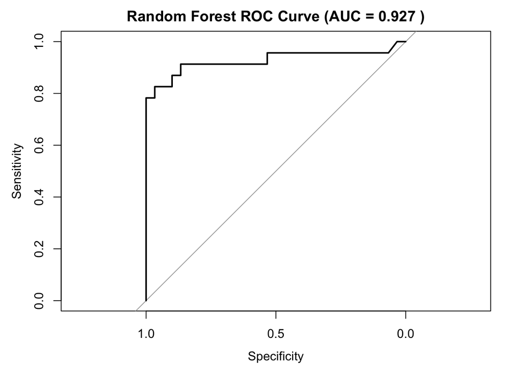

```r
plot(rf_roc, main = paste("Random Forest ROC Curve (AUC =", round(auc(rf_roc), 3), ")"))
```

```r
auc(rf_roc)
```

```
## Area under the curve: 0.9268
```

Interpretation: The variable importance plot highlights the most discriminative genes, while the ROC curve summarizes model performance.

## 8. Support Vector Machine (SVM)

SVMs find the optimal hyperplane that best separates the two classes in a high-dimensional space. They can model complex boundaries via kernel functions.

```r
set.seed(123)
svm_model <- train(TB_Status ~ ., data = train_data,
  method = "svmRadial", metric = "ROC",
  preProcess = c("center", "scale"),
  trControl = ctrl_cv, tuneLength = 10)

svm_model
```

```
## Support Vector Machines with Radial Basis Function Kernel
##
## 126 samples
## 107 predictors
##   2 classes: 'TB', 'LTBI'
##
## Pre-processing: centered (107), scaled (107)
## Resampling: Cross-Validated (5 fold, repeated 3 times)
## Summary of sample sizes: 101, 100, 101, 101, 101, 101, ...
## Resampling results across tuning parameters:
##
##   C       ROC        Sens       Spec
##     0.25  0.9545815  0.8636364  0.9142857
##     0.50  0.9563131  0.8575758  0.9190476
##     1.00  0.9534632  0.8702020  0.9285714
##     2.00  0.9528499  0.8585859  0.9333333
##     4.00  0.9541847  0.8646465  0.9476190
##     8.00  0.9512626  0.8646465  0.9238095
##    16.00  0.9503968  0.8525253  0.9285714
##    32.00  0.9503968  0.8646465  0.9190476
##    64.00  0.9503968  0.8646465  0.9190476
##   128.00  0.9503968  0.8646465  0.9190476
##
## Tuning parameter 'sigma' was held constant at a value of 0.007256767
## ROC was used to select the optimal model using the largest value.
## The final values used for the model were sigma = 0.007256767 and C = 0.5.
```

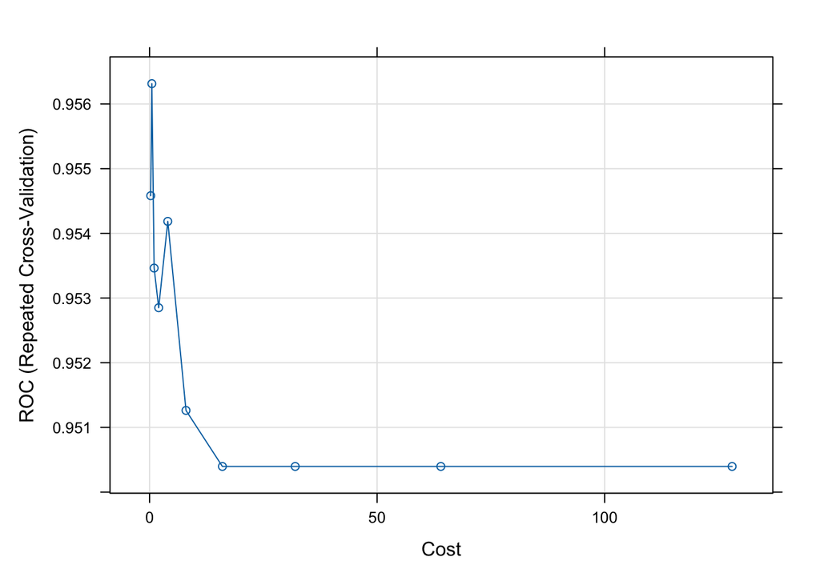

```r
plot(svm_model)
```

```r
# Predictions and performance
svm_pred <- predict(svm_model, test_data)
confusionMatrix(svm_pred, test_data$TB_Status)
```

```
## Confusion Matrix and Statistics
##
##           Reference
## Prediction TB LTBI
##       TB   19    4
##       LTBI  4   26
##
##                Accuracy : 0.8491
##                  95% CI : (0.7241, 0.9325)
##     No Information Rate : 0.566
##     P-Value [Acc > NIR] : 1.077e-05
##
##                   Kappa : 0.6928
##
##  Mcnemar's Test P-Value : 1
##
##             Sensitivity : 0.8261
##             Specificity : 0.8667
##          Pos Pred Value : 0.8261
##          Neg Pred Value : 0.8667
##              Prevalence : 0.4340
##          Detection Rate : 0.3585
##    Detection Prevalence : 0.4340
##       Balanced Accuracy : 0.8464
##
##        'Positive' Class : TB
##
```

```r
# ROC and AUC
svm_probs <- predict(svm_model, test_data, type = "prob")[, "TB"]
svm_roc <- roc(test_data$TB_Status, svm_probs, levels = rev(levels(test_data$TB_Status)))
```

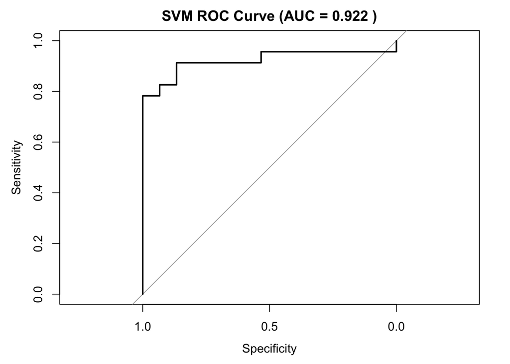

```r
plot(svm_roc, main = paste("SVM ROC Curve (AUC =", round(auc(svm_roc), 3), ")"))
```

```r
auc(svm_roc)
```

```
## Area under the curve: 0.9217
```

## 9. Neural Network (nnet)

Neural networks approximate nonlinear relationships through layers of interconnected nodes (“neurons”). Here we use a simple feed-forward architecture from the `nnet` package via caret.

```r
set.seed(123)
suppressWarnings(
  nnet_model <- train(TB_Status ~ ., data = train_data,
  method = "nnet", metric = "ROC",
  preProcess = c("center", "scale"), trControl = ctrl_cv,
  tuneLength = 10, trace = FALSE)
)

nnet_model
```

```
## Neural Network
##
## 126 samples
## 107 predictors
##   2 classes: 'TB', 'LTBI'
##
## Pre-processing: centered (107), scaled (107)
## Resampling: Cross-Validated (5 fold, repeated 3 times)
## Summary of sample sizes: 101, 100, 101, 101, 101, 101, ...
## Resampling results across tuning parameters:
##
##   size  decay         ROC        Sens       Spec
##    1    0.0000000000  0.9333333  0.8585859  0.9238095
##    1    0.0001000000  0.9483947  0.8828283  0.9238095
##    1    0.0002371374  0.9472042  0.8702020  0.9238095
```

[output cut: 100 more lines]

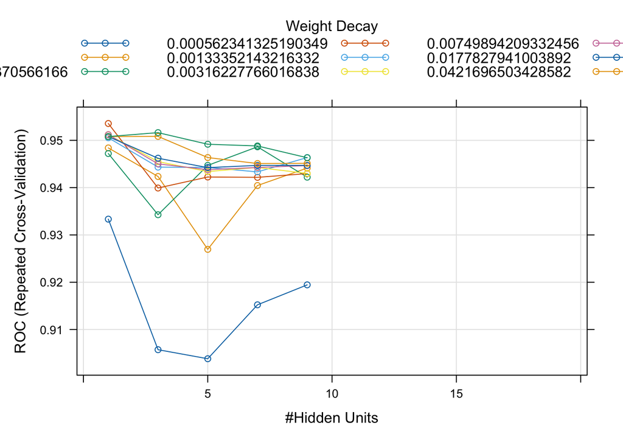

```r
plot(nnet_model)
```

```r
# Predictions and performance
nnet_pred <- predict(nnet_model, test_data)
confusionMatrix(nnet_pred, test_data$TB_Status)
```

```
## Confusion Matrix and Statistics
##
##           Reference
## Prediction TB LTBI
##       TB   16    3
##       LTBI  7   27
##
##                Accuracy : 0.8113
##                  95% CI : (0.6803, 0.9056)
##     No Information Rate : 0.566
##     P-Value [Acc > NIR] : 0.0001519
##
##                   Kappa : 0.608
##
##  Mcnemar's Test P-Value : 0.3427817
##
##             Sensitivity : 0.6957
##             Specificity : 0.9000
##          Pos Pred Value : 0.8421
##          Neg Pred Value : 0.7941
##              Prevalence : 0.4340
##          Detection Rate : 0.3019
##    Detection Prevalence : 0.3585
##       Balanced Accuracy : 0.7978
##
##        'Positive' Class : TB
##
```

```r
# ROC and AUC
nnet_probs <- predict(nnet_model, test_data, type = "prob")[, "TB"]
nnet_roc <- roc(test_data$TB_Status, nnet_probs, levels = rev(levels(test_data$TB_Status)))
```

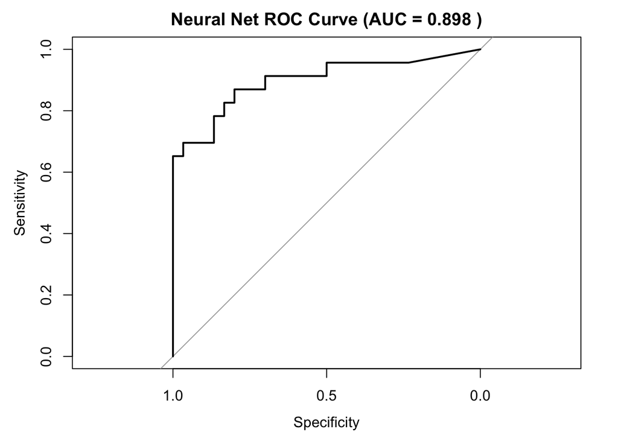

```r
plot(nnet_roc, main = paste("Neural Net ROC Curve (AUC =", round(auc(nnet_roc), 3), ")"))
```

```r
auc(nnet_roc)
```

```
## Area under the curve: 0.8978
```

Interpretation: Neural networks can capture nonlinear relationships but require careful tuning and regularization to avoid overfitting.